# Experimentos de novas visualizações

Juan Carlos Carbajal Ipenza

## 0.1 Tratamento previo

### 0.1.1 Livrarias

```r
library(tidyverse)
library(FactoMineR)
library(factoextra)
library(gplots)
library(geobr)
library(ggplot2)
library(sf)
library(dplyr)
library(crul)
library(streamgraph)
library(Rtsne)
library(stringr)
library(ribge)
library(ggpubr)
library(RColorBrewer)
library(shades)
```

### 0.1.2 Carregando dados

Carregando desde o RData que foi salvo. Selecionando só dados do estado RS. E deletados os fatores que a gente não vai usa como os códigos IBGE dos municipios dos outros estados.

```r
load("output/qdscovid_conditions.Rda")
dados = dados[dados$estadoIBGE == '43',]
dados$estadoIBGE = factor(dados$estadoIBGE)
dados$municipioIBGE = factor(dados$municipioIBGE)
dados$condicoes = factor(dados$condicoes)
head(dados)
```

|  | dataNotificacao | dataInicioSintomas | profissionalSaude | condicoes | estadoTeste | dataTeste | tipoTeste | resultadoTeste | sexo | estadoIBGE | municipioIBGE | estadoNotificacaoIBGE | municipioNotificacaoIBGE | idade | dataEncerramento | evolucaoCaso | classificacaoFinal |
| --- | --- | --- | --- | --- | --- | --- | --- | --- | --- | --- | --- | --- | --- | --- | --- | --- | --- |
| 2123883 | 2020-06-27 | 2020-10-22 | Nao | Doe. card. | Concluido | 2020-06-15 | ANTICORPO | Negativo | Masculino | 43 | 4303905 | Indefinido | Indefinido | 41 | 2020-01-01 | Indefinido | Indefinido |
| 2128114 | 2020-04-08 | 2020-04-06 | Nao | Doe. resp. | Indefinido | 2020-01-01 | Indefinido | Indefinido | Masculino | 43 | 4314902 | Indefinido | Indefinido | 14 | 2020-01-01 | Indefinido | Indefinido |
| 2128115 | 2020-04-08 | 2020-04-06 | Nao | Doe. card. | Indefinido | 2020-01-01 | Indefinido | Indefinido | Masculino | 43 | 4314902 | Indefinido | Indefinido | 14 | 2020-01-01 | Indefinido | Indefinido |
| 2128212 | 2020-05-05 | 2020-05-01 | Nao | Doe. card. | Indefinido | 2020-01-01 | Indefinido | Indefinido | Feminino | 43 | 4320008 | Indefinido | Indefinido | 61 | 2020-01-01 | Indefinido | Indefinido |
| 2128608 | 2020-05-14 | 2020-05-11 | Nao | Imuno. | Indefinido | 2020-01-01 | Indefinido | Indefinido | Feminino | 43 | 4313409 | Indefinido | Indefinido | 41 | 2020-01-01 | Indefinido | Indefinido |
| 2129429 | 2020-06-11 | 2020-06-08 | Nao | Diabetes | Concluido | 2020-06-08 | ANTICORPO | Negativo | Masculino | 43 | 4315503 | Indefinido | Indefinido | 62 | 2020-01-01 | Indefinido | Indefinido |

```r
summary(dados)
```

```
 dataNotificacao      dataInicioSintomas   profissionalSaude      condicoes                    estadoTeste
 Min.   :2020-02-28   Min.   :2020-02-09   Nao:425486        Doe. card.:172987   Coletado            : 37276
 1st Qu.:2020-08-24   1st Qu.:2020-08-16   Sim: 20190        Doe. resp.: 89750   Concluido           :349535
 Median :2020-11-21   Median :2020-11-15                     Diabetes  : 84909   Exame Nao Solicitado:  9891
 Mean   :2020-11-10   Mean   :2020-11-03                     Gestante  : 27155   Solicitado          : 25332
 3rd Qu.:2021-02-02   3rd Qu.:2021-01-26                     Obesidade : 19706   Indefinido          : 23642
 Max.   :2021-03-31   Max.   :2021-03-31                     Imuno.    : 19272
                                                             (Other)   : 31897
   dataTeste               tipoTeste                            resultadoTeste          sexo        estadoIBGE
 Min.   :2020-01-01   ELISA IgM :   230   Inconclusivo ou Indeterminado:   777   Feminino :240988   43:445676
 1st Qu.:2020-07-20   ECLIA IgG :   482   Negativo                     :222704   Masculino:204688
 Median :2020-10-26   CLIA      :    68   Positivo                     :118463
 Mean   :2020-09-27   RT-PCR    :238523   Indefinido                   :103732
 3rd Qu.:2021-01-15   ANTICORPO :110804
 Max.   :2021-03-31   ANTIGENO  : 48898
                      Indefinido: 46671
 municipioIBGE    estadoNotificacaoIBGE municipioNotificacaoIBGE     idade        dataEncerramento
 4314902: 81126   43        :441874     4314902: 89807           Min.   :  0.00   Min.   :2020-01-01
 4304606: 19398   Indefinido:  1831     4304606: 20470           1st Qu.: 37.00   1st Qu.:2020-01-01
 4305108: 17559   41        :   790     4305108: 18509           Median : 53.00   Median :2020-01-01
 4314100: 15461   42        :   380     4314100: 16459           Mean   : 51.16   Mean   :2020-04-06
 4314407: 14610   35        :   289     4314407: 14704           3rd Qu.: 65.00   3rd Qu.:2020-08-10
 4318705: 14575   31        :   140     4316907: 14581           Max.   :116.00   Max.   :2021-03-31
 (Other):282947   (Other)   :   372     (Other):271146
                   evolucaoCaso     classificacaoFinal
 Indefinido              :297800   Cli.-Epid.:   343
 Cura                    : 78360   Cli.-Img. :    58
 Em tratamento domiciliar: 30720   Lab.      :109005
 Cancelado               : 22894   Cri. Cli. :  1372
 Ignorado                : 14283   Desc.     : 74129
 Obito                   :   903   SGNE      : 30297
 (Other)                 :   716   Indefinido:230472
```

## 0.2 Stacked time series

As duas datas consistentes são analisadas.

### 0.2.1 Data de inicio de sintomas

Criada uma tabela de contingencia da data com as condições e depois adiconada a data como fila.

```r
ts_dataInicioSintomas = table(dados$dataInicioSintomas, dados$condicoes)
ts_dataInicioSintomas = as.data.frame.matrix(ts_dataInicioSintomas)

dataInicioSintomas = rownames(ts_dataInicioSintomas)
ts_dataInicioSintomas = cbind(dataInicioSintomas, ts_dataInicioSintomas)
```

E com o esse dataframe é desenhado o stacked time series.

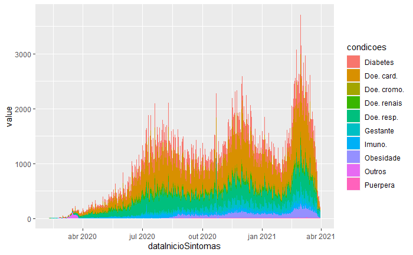

```r
ts_dataInicioSintomas %>%
  mutate(dataInicioSintomas = as.Date(dataInicioSintomas)) %>%
  gather(condicoes, value, levels(dados$condicoes)) %>%
  ggplot(aes(x = dataInicioSintomas, y = value, fill = condicoes)) +
  geom_area()
```

### 0.2.2 Data da notificação

Criada uma tabela de contingencia da data com as condições e depois adicionada a data como fila.

```r
ts_dataNotificacao = table(dados$dataNotificacao, dados$condicoes)
ts_dataNotificacao = as.data.frame.matrix(ts_dataNotificacao)

dataNotificacao = rownames(ts_dataNotificacao)
ts_dataNotificacao = cbind(dataNotificacao, ts_dataNotificacao)
```

E com o esse dataframe é desenhado o stacked time series.

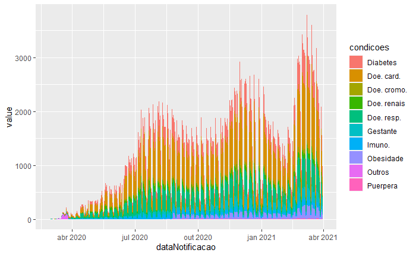

```r
ts_dataNotificacao %>%
  mutate(dataNotificacao = as.Date(dataNotificacao)) %>%
  gather(condicoes, value, levels(dados$condicoes)) %>%
  ggplot(aes(x = dataNotificacao, y = value, fill = condicoes)) +
  geom_area()
```

## 0.3 Stream Graph

As duas datas consistentes são analisadas.

### 0.3.1 Data de inicio de sintomas

Os dados que vamos usar são as contagens de condições por data tanto desde o inicio da pandemia como da última onda.

```r
df_dataInicioSintomas = data.frame(
  dataInicioSintomas = dados$dataInicioSintomas,
  condicoes = as.character(dados$condicoes),
  value = rep(0.5, dim(dados)[1])
)

df_dataInicioSintomas = dados %>% group_by(dataInicioSintomas, condicoes) %>% summarise(n = n())
df_dataInicioSintomas_last_wave = df_dataInicioSintomas[df_dataInicioSintomas$dataInicioSintomas >= "2021-01-01" & df_dataInicioSintomas$dataInicioSintomas <= "2022-01-01",]
```

Stream graph com as datas desde o inicio da pandemia e com uma interpolação cardinal e sem normalização:

```r
streamgraph(df_dataInicioSintomas, key = "condicoes", value = "n", date = "dataInicioSintomas",interpolate="cardinal", offset = "silhouette ", interactive = TRUE) %>%
  sg_fill_brewer("Paired") %>%
  sg_legend(show = TRUE, label = "Condições")
```

```
'offset' does not have a valid value, defaulting to 'silhouette'streamgraph_html returned an object of class `list` instead of a `shiny.tag`.streamgraph_html returned an object of class `list` instead of a `shiny.tag`.
```

[interactive chart not shown]

Stream graph visualizado como normalized stacked bar chart da última onda:

```r
streamgraph(df_dataInicioSintomas_last_wave, key = "condicoes", value = "n", date = "dataInicioSintomas",interpolate="step", offset = "expand", interactive = TRUE) %>%
  sg_fill_brewer("Paired") %>%
  sg_legend(show = TRUE, label = "Condições")
```

```
streamgraph_html returned an object of class `list` instead of a `shiny.tag`.streamgraph_html returned an object of class `list` instead of a `shiny.tag`.
```

[interactive chart not shown]

### 0.3.2 Data da notificação

Os dados que vamos usar são as contagens de condições por data tanto desde o inicio da pandemia como da última onda.

```r
df_dataNotificacao = data.frame(
  dataNotificacao = dados$dataNotificacao,
  condicoes = as.character(dados$condicoes),
  value = rep(0.5, dim(dados)[1])
)

df_dataNotificacao = dados %>% group_by(dataNotificacao, condicoes) %>% summarise(n = n())
df_dataNotificacao_last_wave = df_dataNotificacao[df_dataNotificacao$dataNotificacao >= "2021-01-01" & df_dataNotificacao$dataNotificacao <= "2022-01-01",]
```

Stream graph com as datas desde o inicio da pandemia e com uma interpolação cardinal e sem normalização:

```r
streamgraph(df_dataNotificacao, key = "condicoes", value = "n", date = "dataNotificacao",interpolate="cardinal", offset = "silhouette ", interactive = TRUE) %>%
  sg_fill_brewer("Paired") %>%
  sg_legend(show = TRUE, label = "Condições")
```

```
'offset' does not have a valid value, defaulting to 'silhouette'streamgraph_html returned an object of class `list` instead of a `shiny.tag`.streamgraph_html returned an object of class `list` instead of a `shiny.tag`.
```

[interactive chart not shown]

Stream graph visualizado como normalized stacked bar chart da última onda:

```r
streamgraph(df_dataNotificacao_last_wave, key = "condicoes", value = "n", date = "dataNotificacao",interpolate="step", offset = "expand", interactive = TRUE) %>%
  sg_fill_brewer("Paired") %>%
  sg_legend(show = TRUE, label = "Condições")
```

```
streamgraph_html returned an object of class `list` instead of a `shiny.tag`.streamgraph_html returned an object of class `list` instead of a `shiny.tag`.
```

[interactive chart not shown]

## 0.4 Mapa com coloração predominante

Primeiro, criada uma tabela de contingencia dos municípios e das condições:

```r
contingency_table = table(dados$municipioIBGE, dados$condicoes)
head(contingency_table)
```

```
             Diabetes Doe. card. Doe. renais Doe. resp. Gestante Imuno. Obesidade Doe. cromo. Puerpera Outros
  Indefinido        2          3           4          0        0      1         0           0        0     19
  4300604        2125       4878         528       2687      359    484       406         261        5     20
  4300661           7         23           0          3        6      2         7           3        0      0
  4300703          21         13          12          8       14     10         8           1        0      1
  4300802         127        221          12        133       38     15        12           5        1      0
  4301008         100        314          24         96      103     28        24           7        4      7
```

Desde esta tabela é criado um dataframe dos municípios com a condição predominante:

```r
prop <- function(x) {
  max(x)/sum(x)
}

contingency_table = as.data.frame.matrix(contingency_table)

code_muni = rownames(contingency_table)
condicoes = colnames(contingency_table)[apply(contingency_table,1,which.max)]
condicoes_prop = as.numeric(apply(contingency_table,1, prop))

bestCondition = cbind(code_muni, condicoes, condicoes_prop)
bestCondition = as.data.frame(bestCondition)
bestCondition$code_muni = as.numeric(bestCondition$code_muni)
```

```
NAs introduzidos por coer攼㸷攼㸳o
```

```r
bestCondition$condicoes_prop = as.numeric(bestCondition$condicoes_prop)

head(bestCondition)
```

|  | code_muni | condicoes | condicoes_prop |
| --- | --- | --- | --- |
| 1 | NA | Outros | 0.6551724 |
| 2 | 4300604 | Doe. card. | 0.4150430 |
| 3 | 4300661 | Doe. card. | 0.4509804 |
| 4 | 4300703 | Diabetes | 0.2386364 |
| 5 | 4300802 | Doe. card. | 0.3918440 |
| 6 | 4301008 | Doe. card. | 0.4441301 |

Logo, são baixados os mapas dos municípios e é feito um merge com a tabela gerada anteriormente:

```r
all_muni = read_municipality(code_muni = "RS", year= 2010)
```

```r
all_muni = merge(x = all_muni, y = bestCondition, by = "code_muni", all.x = TRUE)

head(all_muni)
```

```
Simple feature collection with 6 features and 6 fields
Geometry type: MULTIPOLYGON
Dimension:     XY
Bounding box:  xmin: -54.45451 ymin: -33.61653 xmax: -50.53778 ymax: -28.10239
Geodetic CRS:  SIRGAS 2000
  code_muni       name_muni code_state abbrev_state  condicoes condicoes_prop                       geometry
1   4300001     Lagoa Mirim         43           RS       <NA>             NA MULTIPOLYGON (((-52.62242 -...
2   4300002 Lagoa Dos Patos         43           RS       <NA>             NA MULTIPOLYGON (((-52.08379 -...
3   4300034          Aceguá         43           RS Doe. card.      0.5419847 MULTIPOLYGON (((-54.32729 -...
4   4300059      Água Santa         43           RS   Diabetes      0.3269231 MULTIPOLYGON (((-51.98763 -...
5   4300109           Agudo         43           RS Doe. card.      0.4920635 MULTIPOLYGON (((-53.28835 -...
6   4300208       Ajuricaba         43           RS Doe. card.      0.3333333 MULTIPOLYGON (((-53.656 -28...
```

Finalmente, é gerado o mapa com condição predominante:

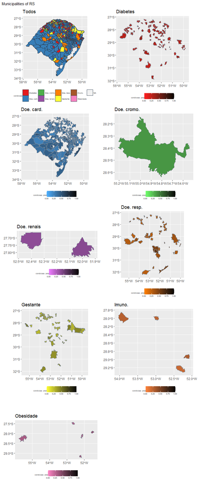

```r
no_axis = theme(axis.title=element_blank(),
                axis.text=element_blank(),
                axis.ticks=element_blank())

colors = brewer.pal(9, "Set1")

cond = levels(as.factor(condicoes))

map_plot <- function(condicao, color) {
  th = theme(legend.position = "bottom", legend.text=element_text(size=5), legend.title=element_text(size=5))

  p = ggplot() + geom_sf(data=all_muni[all_muni$condicoes == condicao,], aes(fill=condicoes_prop), color="#818b96", size=.15, show.legend = TRUE) +
  scale_fill_gradient(limits = c(0.0, 1.0), low = brightness(color, 1.0), high = brightness(color, 0.0)) + ggtitle(condicao)  + th

  return(p)
}

th = theme(legend.position = "bottom", legend.text=element_text(size=5), legend.title=element_text(size=5))

p_ini = ggplot() + geom_sf(data=all_muni, aes(fill=condicoes), color="#2D3E50", size=.15, show.legend = TRUE) +
  scale_fill_manual(values = colors) + ggtitle("Todos")  + th

ggarrange(p_ini,
          map_plot(cond[1], colors[1]),
          map_plot(cond[2], colors[2]),
          map_plot(cond[3], colors[3]),
          map_plot(cond[4], colors[4]),
          map_plot(cond[5], colors[5]),
          map_plot(cond[6], colors[6]),
          map_plot(cond[7], colors[7]),
          map_plot(cond[8], colors[8]), ncol = 2, nrow = 5) +
  labs(subtitle="Municipalities of RS", size=8) +
  theme_minimal() +
  no_axis
```

## 0.5 Redução dimensional: Correspondece Analysis

Ao pesquisar métodos de redução dimensional com dimensões categórias foi achado a seguinte informação: [5 Must-Know Dimensionality Reduction Techniques via Prince](https://towardsdatascience.com/5-must-know-dimensionality-reduction-techniques-via-prince-e6ffb27e55d1)

Desses métodos o melhor que se ajusta a nossos dados e às coisas que a gente mostra é o Correspondece Analysis (CA) technique. Este método é baseado na [tabela de consistencia](https://en.wikipedia.org/wiki/Contingency_table) que é uma matrix de frequencias de duas dimensões. Desde esta tabela é possível gerar o gráfico de redução dimensional.

Esta seção, na parte de código, é baseada na seguinte guia: [CA - Correspondence Analysis in R: Essentials](http://www.sthda.com/english/articles/31-principal-component-methods-in-r-practical-guide/113-ca-correspondence-analysis-in-r-essentials/)

Primeiro, é criada a tabela de contingencia com as dimensões dos municipios e as condições:

```r
contingency_table = table(dados$municipioIBGE, dados$condicoes)
head(contingency_table, n = 10)
```

```
             Diabetes Doe. card. Doe. renais Doe. resp. Gestante Imuno. Obesidade Doe. cromo. Puerpera Outros
  Indefinido        2          3           4          0        0      1         0           0        0     19
  4300604        2125       4878         528       2687      359    484       406         261        5     20
  4300661           7         23           0          3        6      2         7           3        0      0
  4300703          21         13          12          8       14     10         8           1        0      1
  4300802         127        221          12        133       38     15        12           5        1      0
  4301008         100        314          24         96      103     28        24           7        4      7
  4301107          21         25           2         17        3      4         6           2        1      0
  4301636         114        198          22        141       21     24        20          13        2     12
  4301651          26         27          12         14       20      5        14           1        0      0
  4301800          41         31           8         31        9      6        10           3        0      0
```

Logo, é achado o Chi-squared e dá pra ver que os dados tem significativa dependencia entre as dimensões:

```r
chisq.test(contingency_table)
```

```
Aproxima攼㸷攼㸳o do qui-quadrado pode estar incorreta
```

```
    Pearson's Chi-squared test

data:  contingency_table
X-squared = 82800, df = 4473, p-value < 2.2e-16
```

Depois, é calculado o CA:

```r
res.ca = CA(as.data.frame.matrix(contingency_table), graph = FALSE)
```

E finalmente são desenhadas as dimensões no gráfico. Dá pra ver os municípios são azuis e as condições vermelhas. Os códigos dos municípios foram ocultados para mostrar bem o gráfico:

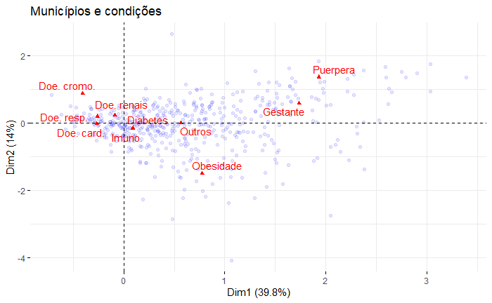

```r
options(ggrepel.max.overlaps = Inf)
fviz_ca_biplot(res.ca, map = "symbiplot", repel = TRUE, label = "col", alpha.row = 0.1, title = "Municípios e condições")
```

Com esse gráfico foi feito um pequeno experimento. É pegado um município que esteja relacionado só com a obesidade:

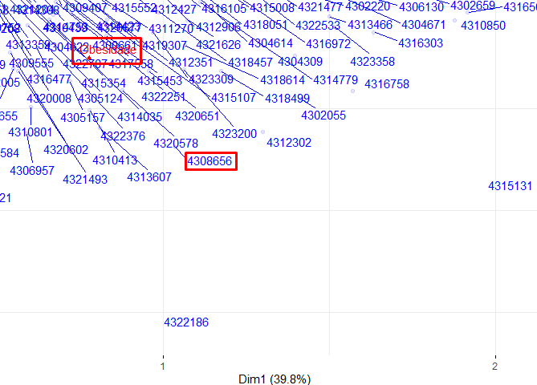

Selecionando um município perto de obesidade

E no QDSCOVID é selecionado só esse município (Garruchos, 4308656) e com isto dá pra ver que a obesidade é o valor predominante:

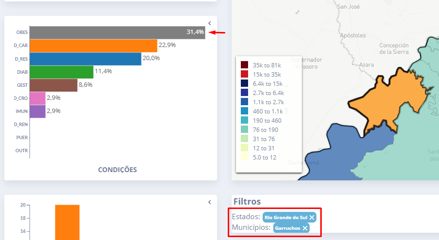

Condições do município Garruchos

## 0.6 Redução dimensional: t-SNE

É gerado um data frame com as contagens de todas as variaveis usadas, menos a idade e as varaiveis temporais:

```r
sum_counties = dados %>%
  group_by(municipioIBGE) %>%
  summarise(n = n())

sum_condicoes = as.data.frame.matrix(table(dados$municipioIBGE, dados$condicoes))
municipioIBGE = rownames(sum_condicoes)
dom_condicoes = colnames(sum_condicoes)[apply(sum_condicoes,1,which.max)]
sum_condicoes = cbind(municipioIBGE, sum_condicoes, dom_condicoes)

sum_sexo = as.data.frame.matrix(table(dados$municipioIBGE, dados$sexo))
municipioIBGE = rownames(sum_sexo)
dom_sexo = colnames(sum_sexo)[apply(sum_sexo,1,which.max)]
sum_sexo = cbind(municipioIBGE, sum_sexo, dom_sexo)

sum_profissionalSaude = as.data.frame.matrix(table(dados$municipioIBGE, dados$profissionalSaude))
municipioIBGE = rownames(sum_profissionalSaude)
dom_profissionalSaude = colnames(sum_profissionalSaude)[apply(sum_profissionalSaude,1,which.max)]
sum_profissionalSaude = cbind(municipioIBGE, sum_profissionalSaude, dom_profissionalSaude)

sum_estadoTeste = as.data.frame.matrix(table(dados$municipioIBGE, dados$estadoTeste))
municipioIBGE = rownames(sum_estadoTeste)
dom_estadoTeste = colnames(sum_estadoTeste)[apply(sum_estadoTeste,1,which.max)]
sum_estadoTeste = cbind(municipioIBGE, sum_estadoTeste, dom_estadoTeste)

sum_tipoTeste = as.data.frame.matrix(table(dados$municipioIBGE, dados$tipoTeste))
municipioIBGE = rownames(sum_tipoTeste)
dom_tipoTeste = colnames(sum_tipoTeste)[apply(sum_tipoTeste,1,which.max)]
sum_tipoTeste = cbind(municipioIBGE, sum_tipoTeste, dom_tipoTeste)

sum_resultadoTeste = as.data.frame.matrix(table(dados$municipioIBGE, dados$resultadoTeste))
municipioIBGE = rownames(sum_resultadoTeste)
dom_resultadoTeste = colnames(sum_resultadoTeste)[apply(sum_resultadoTeste,1,which.max)]
sum_resultadoTeste = cbind(municipioIBGE, sum_resultadoTeste, dom_resultadoTeste)

sum_evolucaoCaso = as.data.frame.matrix(table(dados$municipioIBGE, dados$evolucaoCaso))
municipioIBGE = rownames(sum_evolucaoCaso)
dom_evolucaoCaso = colnames(sum_evolucaoCaso)[apply(sum_evolucaoCaso,1,which.max)]
sum_evolucaoCaso = cbind(municipioIBGE, sum_evolucaoCaso, dom_evolucaoCaso)

sum_classificacaoFinal = as.data.frame.matrix(table(dados$municipioIBGE, dados$classificacaoFinal))
municipioIBGE = rownames(sum_classificacaoFinal)
dom_classificacaoFinal = colnames(sum_classificacaoFinal)[apply(sum_classificacaoFinal,1,which.max)]
sum_classificacaoFinal = cbind(municipioIBGE, sum_classificacaoFinal, dom_classificacaoFinal)

sum_data = sum_counties %>%
  inner_join(sum_condicoes, by = "municipioIBGE") %>%
  inner_join(sum_sexo, by = "municipioIBGE") %>%
  inner_join(sum_profissionalSaude, by = "municipioIBGE") %>%
  inner_join(sum_estadoTeste, by = "municipioIBGE") %>%
  inner_join(sum_tipoTeste, by = "municipioIBGE") %>%
  inner_join(sum_resultadoTeste, by = "municipioIBGE") %>%
  inner_join(sum_evolucaoCaso, by = "municipioIBGE") %>%
  inner_join(sum_classificacaoFinal, by = "municipioIBGE")

head(sum_data)
```

| municipioIBGE | n | Diabetes | Doe. card. | Doe. renais | Doe. resp. | Gestante | Imuno. | Obesidade | Doe. cromo. | Puerpera | Outros | dom_condicoes | Feminino | Masculino | dom_sexo | Nao | Sim | dom_profissionalSaude | Coletado | Concluido | Exame Nao Solicitado | Solicitado | Indefinido.x | dom_estadoTeste | ELISA IgM | ECLIA IgG | CLIA | RT-PCR | ANTICORPO | … |
| --- | --- | --- | --- | --- | --- | --- | --- | --- | --- | --- | --- | --- | --- | --- | --- | --- | --- | --- | --- | --- | --- | --- | --- | --- | --- | --- | --- | --- | --- | --- |
| Indefinido | 29 | 2 | 3 | 4 | 0 | 0 | 1 | 0 | 0 | 0 | 19 | Outros | 14 | 15 | Masculino | 27 | 2 | Nao | 14 | 13 | 0 | 0 | 2 | Coletado | 0 | 0 | 0 | 24 | 5 | … |
| 4300604 | 11753 | 2125 | 4878 | 528 | 2687 | 359 | 484 | 406 | 261 | 5 | 20 | Doe. card. | 7482 | 4271 | Feminino | 11205 | 548 | Nao | 1882 | 9117 | 48 | 352 | 354 | Concluido | 6 | 0 | 0 | 8571 | 1814 | … |
| 4300661 | 51 | 7 | 23 | 0 | 3 | 6 | 2 | 7 | 3 | 0 | 0 | Doe. card. | 38 | 13 | Feminino | 48 | 3 | Nao | 0 | 43 | 0 | 4 | 4 | Concluido | 1 | 0 | 0 | 16 | 20 | … |
| 4300703 | 88 | 21 | 13 | 12 | 8 | 14 | 10 | 8 | 1 | 0 | 1 | Diabetes | 53 | 35 | Feminino | 88 | 0 | Nao | 6 | 77 | 0 | 4 | 1 | Concluido | 0 | 0 | 0 | 33 | 28 | … |
| 4300802 | 564 | 127 | 221 | 12 | 133 | 38 | 15 | 12 | 5 | 1 | 0 | Doe. card. | 353 | 211 | Feminino | 556 | 8 | Nao | 22 | 486 | 0 | 55 | 1 | Concluido | 0 | 0 | 0 | 317 | 195 | … |
| 4301008 | 707 | 100 | 314 | 24 | 96 | 103 | 28 | 24 | 7 | 4 | 7 | Doe. card. | 460 | 247 | Feminino | 679 | 28 | Nao | 22 | 529 | 50 | 12 | 94 | Concluido | 0 | 0 | 0 | 414 | 101 | … |

É gerado outro data frame com a população dos municipios:

```r
population = populacao_municipios(2011)
population = population[population$uf == "RS",]
population = population[, names(population) %in% c("cod_municipio", "populacao")]
colnames(population) = c("population", "municipioIBGE")
population$municipioIBGE = as.character(population$municipioIBGE)

head(population)
```

| population | municipioIBGE |
| --- | --- |
| 4430 | 4300034 |
| 3717 | 4300059 |
| 16666 | 4300109 |
| 7220 | 4300208 |
| 6934 | 4300307 |
| 77140 | 4300406 |

É feito um merge do data frame de dadso com a população;

```r
sum_data = sum_data %>% inner_join(population, by = "municipioIBGE")
head(sum_data)
```

| municipioIBGE | n | Diabetes | Doe. card. | Doe. renais | Doe. resp. | Gestante | Imuno. | Obesidade | Doe. cromo. | Puerpera | Outros | dom_condicoes | Feminino | Masculino | dom_sexo | Nao | Sim | dom_profissionalSaude | Coletado | Concluido | Exame Nao Solicitado | Solicitado | Indefinido.x | dom_estadoTeste | ELISA IgM | ECLIA IgG | CLIA | RT-PCR | ANTICORPO | … |
| --- | --- | --- | --- | --- | --- | --- | --- | --- | --- | --- | --- | --- | --- | --- | --- | --- | --- | --- | --- | --- | --- | --- | --- | --- | --- | --- | --- | --- | --- | --- |
| 4300604 | 11753 | 2125 | 4878 | 528 | 2687 | 359 | 484 | 406 | 261 | 5 | 20 | Doe. card. | 7482 | 4271 | Feminino | 11205 | 548 | Nao | 1882 | 9117 | 48 | 352 | 354 | Concluido | 6 | 0 | 0 | 8571 | 1814 | … |
| 4300661 | 51 | 7 | 23 | 0 | 3 | 6 | 2 | 7 | 3 | 0 | 0 | Doe. card. | 38 | 13 | Feminino | 48 | 3 | Nao | 0 | 43 | 0 | 4 | 4 | Concluido | 1 | 0 | 0 | 16 | 20 | … |
| 4300703 | 88 | 21 | 13 | 12 | 8 | 14 | 10 | 8 | 1 | 0 | 1 | Diabetes | 53 | 35 | Feminino | 88 | 0 | Nao | 6 | 77 | 0 | 4 | 1 | Concluido | 0 | 0 | 0 | 33 | 28 | … |
| 4300802 | 564 | 127 | 221 | 12 | 133 | 38 | 15 | 12 | 5 | 1 | 0 | Doe. card. | 353 | 211 | Feminino | 556 | 8 | Nao | 22 | 486 | 0 | 55 | 1 | Concluido | 0 | 0 | 0 | 317 | 195 | … |
| 4301008 | 707 | 100 | 314 | 24 | 96 | 103 | 28 | 24 | 7 | 4 | 7 | Doe. card. | 460 | 247 | Feminino | 679 | 28 | Nao | 22 | 529 | 50 | 12 | 94 | Concluido | 0 | 0 | 0 | 414 | 101 | … |
| 4301107 | 81 | 21 | 25 | 2 | 17 | 3 | 4 | 6 | 2 | 1 | 0 | Doe. card. | 49 | 32 | Feminino | 74 | 7 | Nao | 3 | 74 | 2 | 0 | 2 | Concluido | 0 | 0 | 0 | 29 | 19 | … |

São geradas duas matrizes. Uma dividendo as contagens entre a contagem desse municipio e a outra matriz fazendo o mesmo com a densidade desse municipio:

```r
sum_matrix_base = data.matrix(subset(sum_data[, !str_detect(names(sum_data), "dom_")], select = -c(municipioIBGE, n, population)))

sum_matrix = sum_matrix_base / sum_data$n
sum_matrix_pop = cbind(sum_data$n/sum_data$population, sum_matrix_base / sum_data$n)

head(as.data.frame(sum_matrix))
```

|  | Diabetes | Doe. card. | Doe. renais | Doe. resp. | Gestante | Imuno. | Obesidade | Doe. cromo. | Puerpera | Outros | Feminino | Masculino | Nao | Sim | Coletado | Concluido | Exame Nao Solicitado | Solicitado | Indefinido.x | ELISA IgM | ECLIA IgG | CLIA | RT-PCR | ANTICORPO | ANTIGENO | Indefinido.y | Inconclusivo ou Indeterminado | Negativo | Positivo | … |
| --- | --- | --- | --- | --- | --- | --- | --- | --- | --- | --- | --- | --- | --- | --- | --- | --- | --- | --- | --- | --- | --- | --- | --- | --- | --- | --- | --- | --- | --- | --- |
| 1 | 0.1808049 | 0.4150430 | 0.04492470 | 0.22862248 | 0.03054539 | 0.04118098 | 0.03454437 | 0.022207096 | 0.0004254233 | 0.001701693 | 0.6366034 | 0.3633966 | 0.9533736 | 0.04662639 | 0.16012933 | 0.7757168 | 0.004084064 | 0.02994980 | 0.03011997 | 0.000510508 | 0 | 0 | 0.7292606 | 0.1543436 | 0.03003488 | 0.08585042 | 0.007912873 | 0.4691568 | 0.2797584 | … |
| 2 | 0.1372549 | 0.4509804 | 0.00000000 | 0.05882353 | 0.11764706 | 0.03921569 | 0.13725490 | 0.058823529 | 0.0000000000 | 0.000000000 | 0.7450980 | 0.2549020 | 0.9411765 | 0.05882353 | 0.00000000 | 0.8431373 | 0.000000000 | 0.07843137 | 0.07843137 | 0.019607843 | 0 | 0 | 0.3137255 | 0.3921569 | 0.13725490 | 0.13725490 | 0.000000000 | 0.5490196 | 0.2941176 | … |
| 3 | 0.2386364 | 0.1477273 | 0.13636364 | 0.09090909 | 0.15909091 | 0.11363636 | 0.09090909 | 0.011363636 | 0.0000000000 | 0.011363636 | 0.6022727 | 0.3977273 | 1.0000000 | 0.00000000 | 0.06818182 | 0.8750000 | 0.000000000 | 0.04545455 | 0.01136364 | 0.000000000 | 0 | 0 | 0.3750000 | 0.3181818 | 0.20454545 | 0.10227273 | 0.000000000 | 0.4772727 | 0.3636364 | … |
| 4 | 0.2251773 | 0.3918440 | 0.02127660 | 0.23581560 | 0.06737589 | 0.02659574 | 0.02127660 | 0.008865248 | 0.0017730496 | 0.000000000 | 0.6258865 | 0.3741135 | 0.9858156 | 0.01418440 | 0.03900709 | 0.8617021 | 0.000000000 | 0.09751773 | 0.00177305 | 0.000000000 | 0 | 0 | 0.5620567 | 0.3457447 | 0.05673759 | 0.03546099 | 0.001773050 | 0.5939716 | 0.2641844 | … |
| 5 | 0.1414427 | 0.4441301 | 0.03394625 | 0.13578501 | 0.14568600 | 0.03960396 | 0.03394625 | 0.009900990 | 0.0056577086 | 0.009900990 | 0.6506365 | 0.3493635 | 0.9603960 | 0.03960396 | 0.03111740 | 0.7482320 | 0.070721358 | 0.01697313 | 0.13295615 | 0.000000000 | 0 | 0 | 0.5855728 | 0.1428571 | 0.05940594 | 0.21216407 | 0.000000000 | 0.4356436 | 0.3012730 | … |
| 6 | 0.2592593 | 0.3086420 | 0.02469136 | 0.20987654 | 0.03703704 | 0.04938272 | 0.07407407 | 0.024691358 | 0.0123456790 | 0.000000000 | 0.6049383 | 0.3950617 | 0.9135802 | 0.08641975 | 0.03703704 | 0.9135802 | 0.024691358 | 0.00000000 | 0.02469136 | 0.000000000 | 0 | 0 | 0.3580247 | 0.2345679 | 0.25925926 | 0.14814815 | 0.000000000 | 0.5432099 | 0.3086420 | … |

```r
head(as.data.frame(sum_matrix_pop))
```

|  | V1 | Diabetes | Doe. card. | Doe. renais | Doe. resp. | Gestante | Imuno. | Obesidade | Doe. cromo. | Puerpera | Outros | Feminino | Masculino | Nao | Sim | Coletado | Concluido | Exame Nao Solicitado | Solicitado | Indefinido.x | ELISA IgM | ECLIA IgG | CLIA | RT-PCR | ANTICORPO | ANTIGENO | Indefinido.y | Inconclusivo ou Indeterminado | Negativo | … |
| --- | --- | --- | --- | --- | --- | --- | --- | --- | --- | --- | --- | --- | --- | --- | --- | --- | --- | --- | --- | --- | --- | --- | --- | --- | --- | --- | --- | --- | --- | --- |
| 1 | 0.059790101 | 0.1808049 | 0.4150430 | 0.04492470 | 0.22862248 | 0.03054539 | 0.04118098 | 0.03454437 | 0.022207096 | 0.0004254233 | 0.001701693 | 0.6366034 | 0.3633966 | 0.9533736 | 0.04662639 | 0.16012933 | 0.7757168 | 0.004084064 | 0.02994980 | 0.03011997 | 0.000510508 | 0 | 0 | 0.7292606 | 0.1543436 | 0.03003488 | 0.08585042 | 0.007912873 | 0.4691568 | … |
| 2 | 0.041666667 | 0.1372549 | 0.4509804 | 0.00000000 | 0.05882353 | 0.11764706 | 0.03921569 | 0.13725490 | 0.058823529 | 0.0000000000 | 0.000000000 | 0.7450980 | 0.2549020 | 0.9411765 | 0.05882353 | 0.00000000 | 0.8431373 | 0.000000000 | 0.07843137 | 0.07843137 | 0.019607843 | 0 | 0 | 0.3137255 | 0.3921569 | 0.13725490 | 0.13725490 | 0.000000000 | 0.5490196 | … |
| 3 | 0.014535844 | 0.2386364 | 0.1477273 | 0.13636364 | 0.09090909 | 0.15909091 | 0.11363636 | 0.09090909 | 0.011363636 | 0.0000000000 | 0.011363636 | 0.6022727 | 0.3977273 | 1.0000000 | 0.00000000 | 0.06818182 | 0.8750000 | 0.000000000 | 0.04545455 | 0.01136364 | 0.000000000 | 0 | 0 | 0.3750000 | 0.3181818 | 0.20454545 | 0.10227273 | 0.000000000 | 0.4772727 | … |
| 4 | 0.043973179 | 0.2251773 | 0.3918440 | 0.02127660 | 0.23581560 | 0.06737589 | 0.02659574 | 0.02127660 | 0.008865248 | 0.0017730496 | 0.000000000 | 0.6258865 | 0.3741135 | 0.9858156 | 0.01418440 | 0.03900709 | 0.8617021 | 0.000000000 | 0.09751773 | 0.00177305 | 0.000000000 | 0 | 0 | 0.5620567 | 0.3457447 | 0.05673759 | 0.03546099 | 0.001773050 | 0.5939716 | … |
| 5 | 0.037359966 | 0.1414427 | 0.4441301 | 0.03394625 | 0.13578501 | 0.14568600 | 0.03960396 | 0.03394625 | 0.009900990 | 0.0056577086 | 0.009900990 | 0.6506365 | 0.3493635 | 0.9603960 | 0.03960396 | 0.03111740 | 0.7482320 | 0.070721358 | 0.01697313 | 0.13295615 | 0.000000000 | 0 | 0 | 0.5855728 | 0.1428571 | 0.05940594 | 0.21216407 | 0.000000000 | 0.4356436 | … |
| 6 | 0.005944082 | 0.2592593 | 0.3086420 | 0.02469136 | 0.20987654 | 0.03703704 | 0.04938272 | 0.07407407 | 0.024691358 | 0.0123456790 | 0.000000000 | 0.6049383 | 0.3950617 | 0.9135802 | 0.08641975 | 0.03703704 | 0.9135802 | 0.024691358 | 0.00000000 | 0.02469136 | 0.000000000 | 0 | 0 | 0.3580247 | 0.2345679 | 0.25925926 | 0.14814815 | 0.000000000 | 0.5432099 | … |

Calculando os valores do t-SNE para diferentes perplexidades e iterações para a matriz normal e a matriz de densidade:

```r
tsne_out_5_1k <- Rtsne(sum_matrix, perplexity = 5,theta = 0.0, max_iter = 1000, verbose = FALSE)
tsne_out_5_5k <- Rtsne(sum_matrix, perplexity = 5,theta = 0.0, max_iter = 5000, verbose = FALSE)
tsne_out_30_1k <- Rtsne(sum_matrix, perplexity = 30,theta = 0.0, max_iter = 1000, verbose = FALSE)
tsne_out_30_5k <- Rtsne(sum_matrix, perplexity = 30,theta = 0.0, max_iter = 5000, verbose = FALSE)
tsne_out_50_1k <- Rtsne(sum_matrix, perplexity = 50,theta = 0.0, max_iter = 1000, verbose = FALSE)
tsne_out_50_5k <- Rtsne(sum_matrix, perplexity = 50,theta = 0.0, max_iter = 5000, verbose = FALSE)

tsne_out_pop_5_1k <- Rtsne(sum_matrix_pop, perplexity = 5,theta = 0.0, max_iter = 1000, verbose = FALSE)
tsne_out_pop_5_5k <- Rtsne(sum_matrix_pop, perplexity = 5,theta = 0.0, max_iter = 5000, verbose = FALSE)
tsne_out_pop_30_1k <- Rtsne(sum_matrix_pop, perplexity = 30,theta = 0.0, max_iter = 1000, verbose = FALSE)
tsne_out_pop_30_5k <- Rtsne(sum_matrix_pop, perplexity = 30,theta = 0.0, max_iter = 5000, verbose = FALSE)
tsne_out_pop_50_1k <- Rtsne(sum_matrix_pop, perplexity = 50,theta = 0.0, max_iter = 1000, verbose = FALSE)
tsne_out_pop_50_5k <- Rtsne(sum_matrix_pop, perplexity = 50,theta = 0.0, max_iter = 5000, verbose = FALSE)
```

Criando a função que vai gerar os gráficos de cada t-SNE:

```r
plot_tsne <- function(tsne_out, title = "") {
  tsne_plot = data.frame(x = tsne_out$Y[,1], y = tsne_out$Y[,2],
                         condicoes = sum_data$dom_condicoes,
                         sexo = sum_data$dom_sexo,
                         profissionalSaude = sum_data$dom_profissionalSaude,
                         estadoTeste = sum_data$dom_estadoTeste,
                         tipoTeste = sum_data$dom_tipoTeste,
                         resultadoTeste = sum_data$dom_resultadoTeste,
                         evolucaoCaso = sum_data$dom_evolucaoCaso,
                         classificacaoFinal = sum_data$dom_classificacaoFinal)

  th = theme(legend.position = "bottom", legend.text=element_text(size=5), legend.title=element_text(size=5))

  p1 = ggplot(tsne_plot) + geom_point(aes(x = x, y = y, color = condicoes)) + th
  p2 = ggplot(tsne_plot) + geom_point(aes(x = x, y = y, color = sexo)) + th
  p3 = ggplot(tsne_plot) + geom_point(aes(x = x, y = y, color = profissionalSaude)) + th
  p4 = ggplot(tsne_plot) + geom_point(aes(x = x, y = y, color = estadoTeste)) + th
  p5 = ggplot(tsne_plot) + geom_point(aes(x = x, y = y, color = tipoTeste)) + th
  p6 = ggplot(tsne_plot) + geom_point(aes(x = x, y = y, color = resultadoTeste)) + th
  p7 = ggplot(tsne_plot) + geom_point(aes(x = x, y = y, color = evolucaoCaso)) + th
  p8 = ggplot(tsne_plot) + geom_point(aes(x = x, y = y, color = classificacaoFinal)) + th


  figure = ggarrange(p1, p2, p3, p4, p5, p6, p7, p8, ncol = 2, nrow = 4)

  title_final = paste(title, ", cost=", as.character(tail(tsne_out$itercosts, n = 1)), sep = "")

  annotate_figure(figure, top = text_grob(title_final, color = "black", face = "bold", size = 14))
}
```

Printando os gráficos:

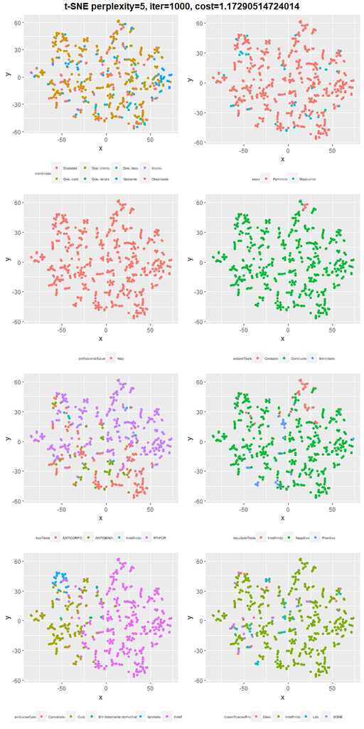

```r
plot_tsne(tsne_out_5_1k, title = "t-SNE perplexity=5, iter=1000")
```

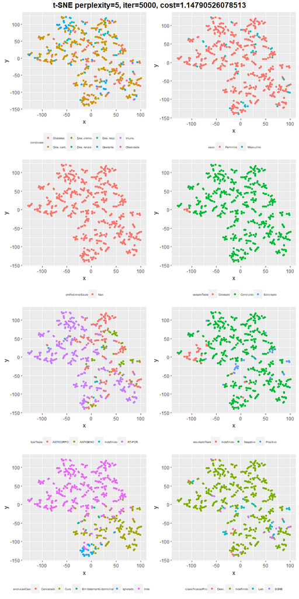

```r
plot_tsne(tsne_out_5_5k, title = "t-SNE perplexity=5, iter=5000")
```

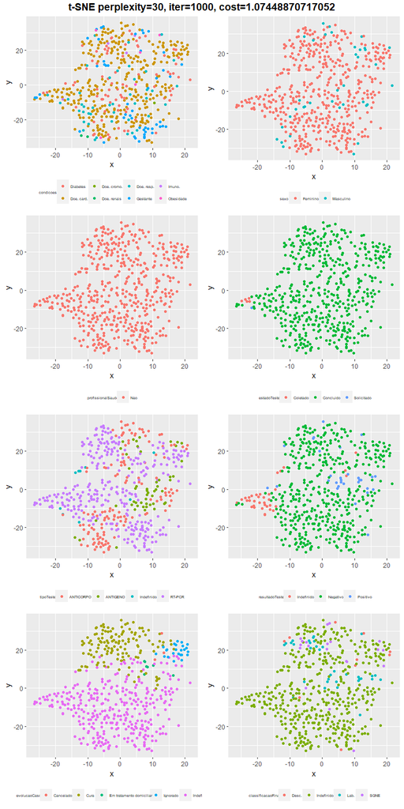

```r
plot_tsne(tsne_out_30_1k, title = "t-SNE perplexity=30, iter=1000")
```

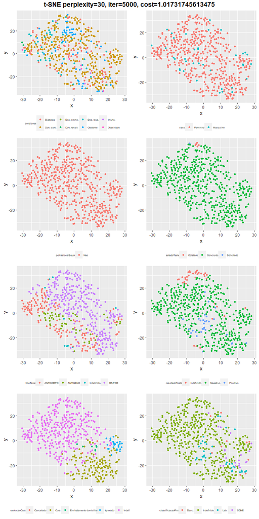

```r
plot_tsne(tsne_out_30_5k, title = "t-SNE perplexity=30, iter=5000")
```

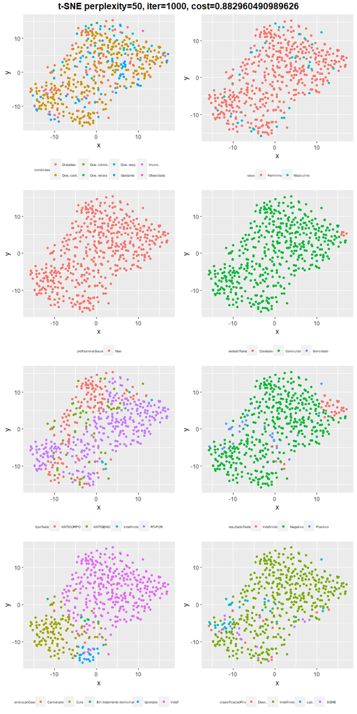

```r
plot_tsne(tsne_out_50_1k, title = "t-SNE perplexity=50, iter=1000")
```

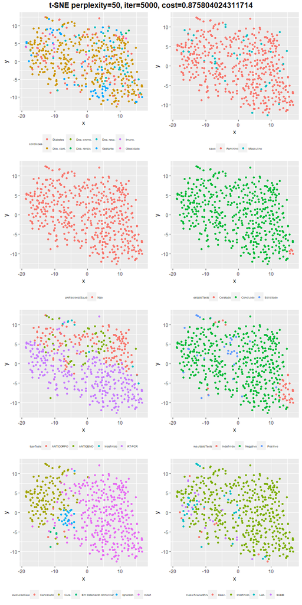

```r
plot_tsne(tsne_out_50_5k, title = "t-SNE perplexity=50, iter=5000")
```

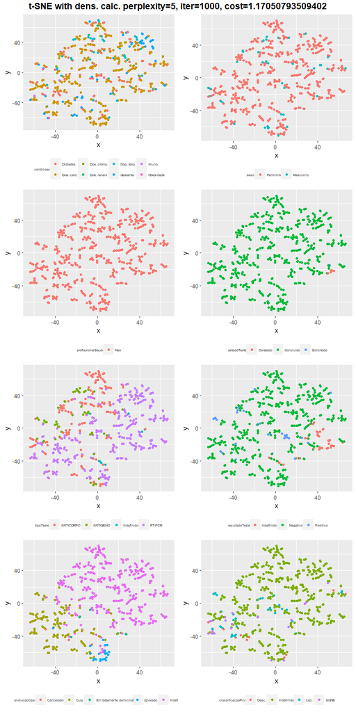

```r
plot_tsne(tsne_out_pop_5_1k, title = "t-SNE with dens. calc. perplexity=5, iter=1000")
```

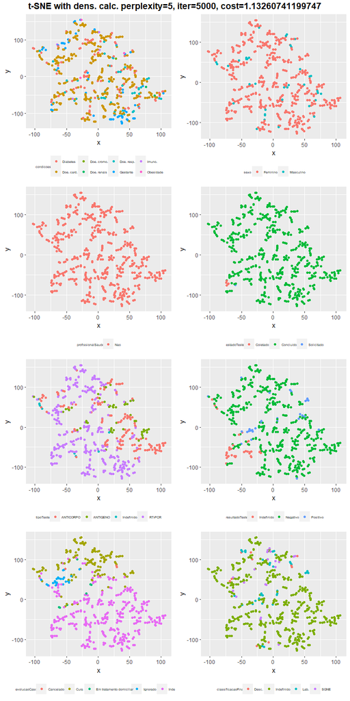

```r
plot_tsne(tsne_out_pop_5_5k, title = "t-SNE with dens. calc. perplexity=5, iter=5000")
```

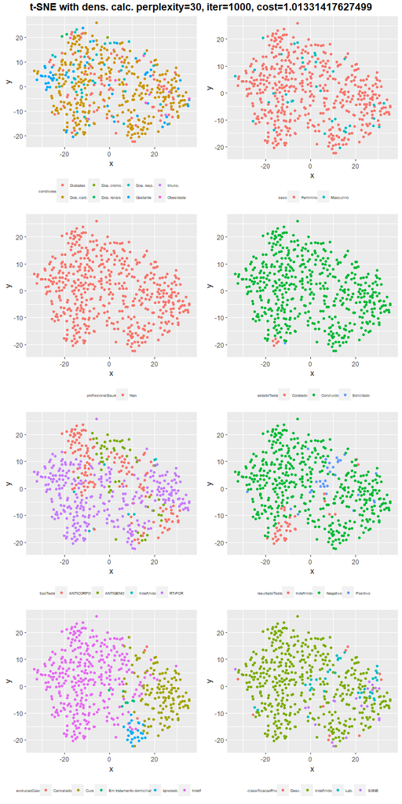

```r
plot_tsne(tsne_out_pop_30_1k, title = "t-SNE with dens. calc. perplexity=30, iter=1000")
```

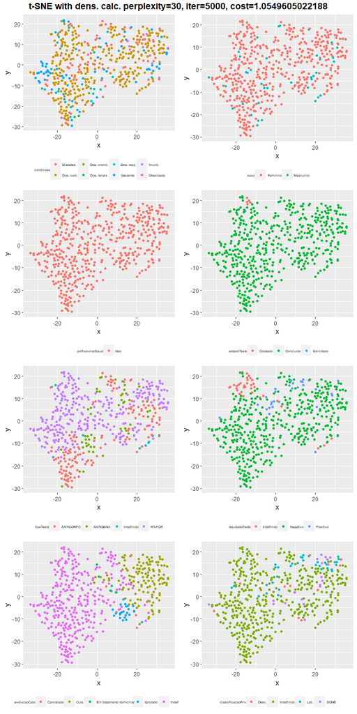

```r
plot_tsne(tsne_out_pop_30_5k, title = "t-SNE with dens. calc. perplexity=30, iter=5000")
```

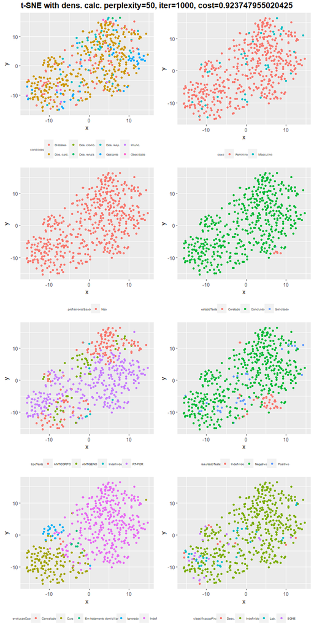

```r
plot_tsne(tsne_out_pop_50_1k, title = "t-SNE with dens. calc. perplexity=50, iter=1000")
```

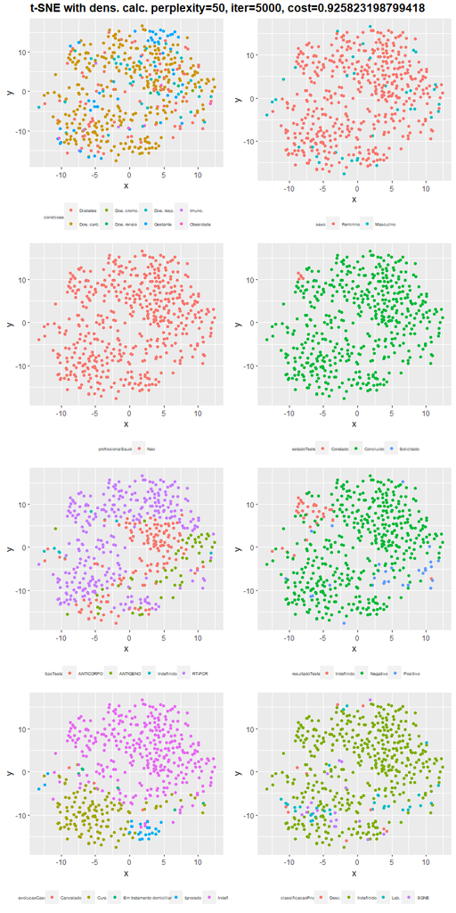

```r
plot_tsne(tsne_out_pop_50_5k, title = "t-SNE with dens. calc. perplexity=50, iter=5000")
```